# GERMINACIÓN DE SEMILLAS DE HABAS (*Vicia Faba*) BAJO EFECTO DE PRESENCIA Y AUSENCIA DE LUZ

Author

Arista Fernandez Hector, Perez Campos Elda, Tomapasca Lopez Frank, Vega Chavez Gimena y Vilchez Bustamante Erik

# 1 INTRODUCCIÓN

La haba (Vicia faba L.) es una leguminosa originaria del centro y sur de Asia (Saavedra & Kehr, 2023). Es un cultivo anual que posee un tallo erecto y puede alcanzar alturas de entre 1.5 a 2 m (Arnaud & Georges, 2020); fue introducida en el continente americano en la época de la colonia en 1602 (Horque, 2004). En el Perú el cultivo de haba es de suma importancia; específicamente en la sierra del Perú; este cultivo se ha expandido en los últimos años hasta alcanzar un área de más de 34,000 ha (INIA, 2004). Solo en agosto del 2024 la producción de habas alcanzó las 303 toneladas y se exportó a ocho países (Agraria.pe, 2024). En los últimos años se ha observado un gran crecimiento en la producción de habas debido a la alta demanda que esta generando; es por ello que se debe optimizar y perfeccionar las técnicas de producción especialmente analizando su comportamiento germinativo bajo condiciones de luz y oscuridad.

# 2 OBJETIVO

## 2.1 Objetivo general

Analizar el efecto de la luminosidad y la oscuridad en el proceso de germinación de semillas de haba (*Vicia faba* L.).

## 2.2 Objetivos especificos

- Comparar el tiempo medio de germinación entre semillas expuestas a luz y aquellas en ausencia de luz.
- Determinar el índice de sincronización de la germinación de semillas de haba en ambos tratamientos (luz y oscuridad).
- Analizar si existen diferencias significativas en la germinación de semillas de haba debido a la presencia o ausencia de luz.

# 3 MATERIALES Y MÉTODOS

## 3.1 Materiales

- Semillas de Habas
- Agua
- Papel toalla
- Taper de 1 Kg
- Papel aluminio
- Sulfato de cobre
- Geringa de 20 ml
- Pinza
- Regla

## 3.2 Metodología

Las semillas de haba (*Vicia faba* L.) fueron adquiridas en el mercado modelo de la ciudad de Chachapoyas y seleccionadas manualmente, priorizando aquellas que presentaban buen tamaño y un aspecto saludable.

El experimento se desarrolló utilizando 12 recipientes plásticos, divididos en dos tratamientos: seis recipientes forrados internamente con papel aluminio para generar condiciones de oscuridad, y seis expuestos a la luz ambiental normal, con el objetivo de comparar el efecto de la iluminación sobre la germinación.

Para identificar claramente los dos tratamientos, se elaboraron etiquetas en RStudio con las leyendas “Luz” y “Sin luz”, lo que facilitó un seguimiento organizado y preciso del comportamiento de cada grupo de semillas bajo sus respectivas condiciones de iluminación.

[figure not shown]

# 4 RESULTADOS

La germinación de las semillas durante los siete días muestra que se cumplen las características de una semilla germinada correctamente. Se observa en ambas imágenes que la germinación se dio con éxito, tanto en presencia de luz como en oscuridad.

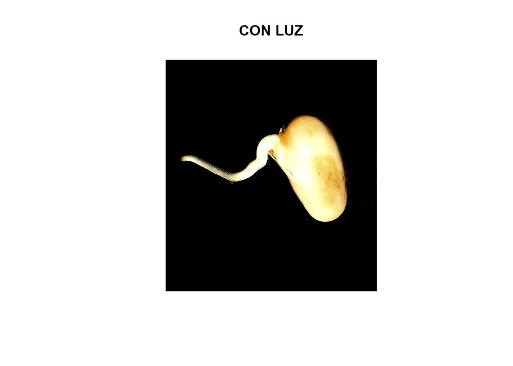

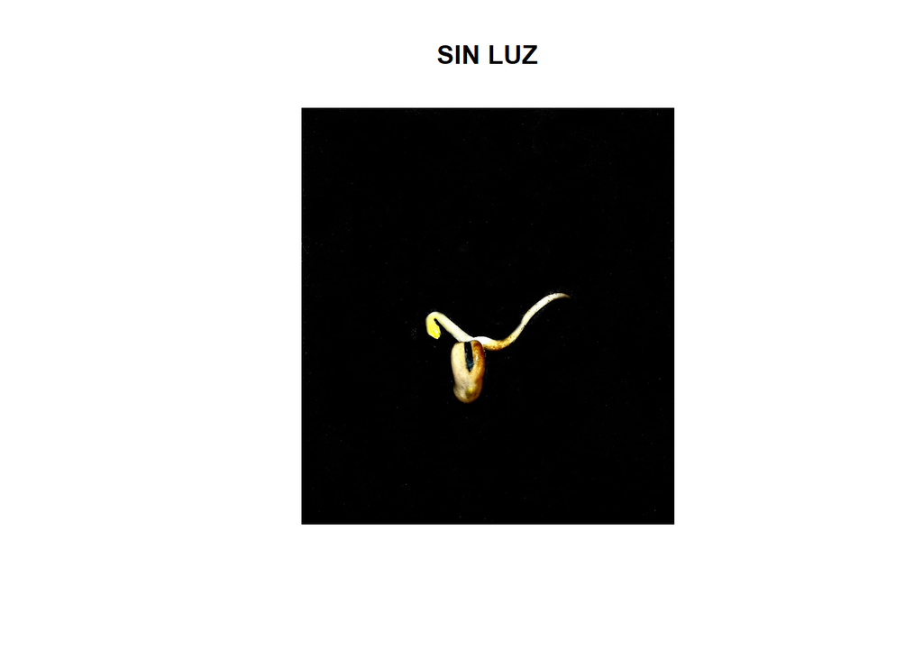

**ORGANIZACIÓNN DE DATA**

```
# A tibble: 6 × 14
    Rep Factor  Temp seeds   grs   grp mgt   mgr     gsp unc   syn   vgt     sdg
  <dbl> <chr>  <dbl> <dbl> <dbl> <dbl> <lis> <lis> <dbl> <lis> <lis> <lis> <dbl>
1     1 Sin l…    25    25    24    96 <dbl> <dbl> 16667 <dbl> <dbl> <dbl>  1142
2     2 Con l…    25    25    24    96 <dbl> <dbl> 17143 <dbl> <dbl> <dbl>   637
3     3 Con l…    25    25    25   100 <chr> <dbl> 20661 <dbl> <chr> <dbl>  1405
4     4 Sin l…    25    25    23    92 <dbl> <dbl> 17293 <dbl> <dbl> <dbl>  1313
5     5 Sin l…    25    25    21    84 <dbl> <dbl> 18261 <chr> <dbl> <dbl>  1436
6     6 Con l…    25    25    24    96 <dbl> <dbl> 19672 <dbl> <dbl> <dbl>   929
# ℹ 1 more variable: cvg <list>
```

**GERMINABILIDAD**

Exploratorio

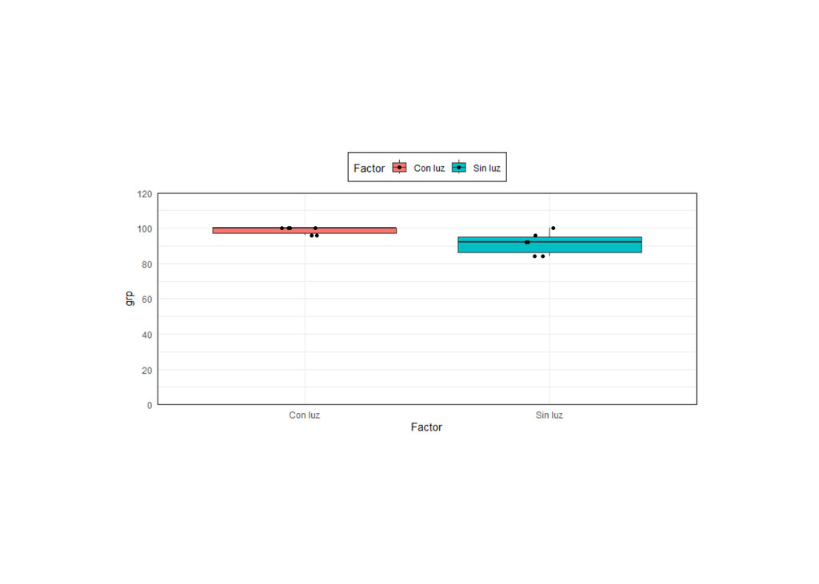

En el gráfico se observa que en el eje X se representan dos tratamientos: con luz y sin luz, mientras que en el eje Y se muestra el valor de GRP (porcentaje de germinación). Cada punto negro corresponde a una observación individual, es decir, a una réplica experimental.

En consecuencia, se puede concluir que la presencia de luz favorece no solo un mayor porcentaje de germinación, sino también una mayor uniformidad en la respuesta de las semillas de haba, en comparación con las condiciones de oscuridad.

Estadísticas

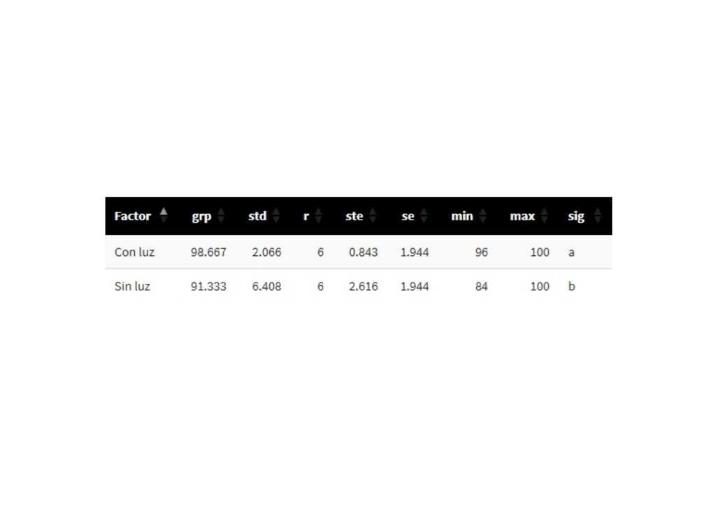

Gráfico

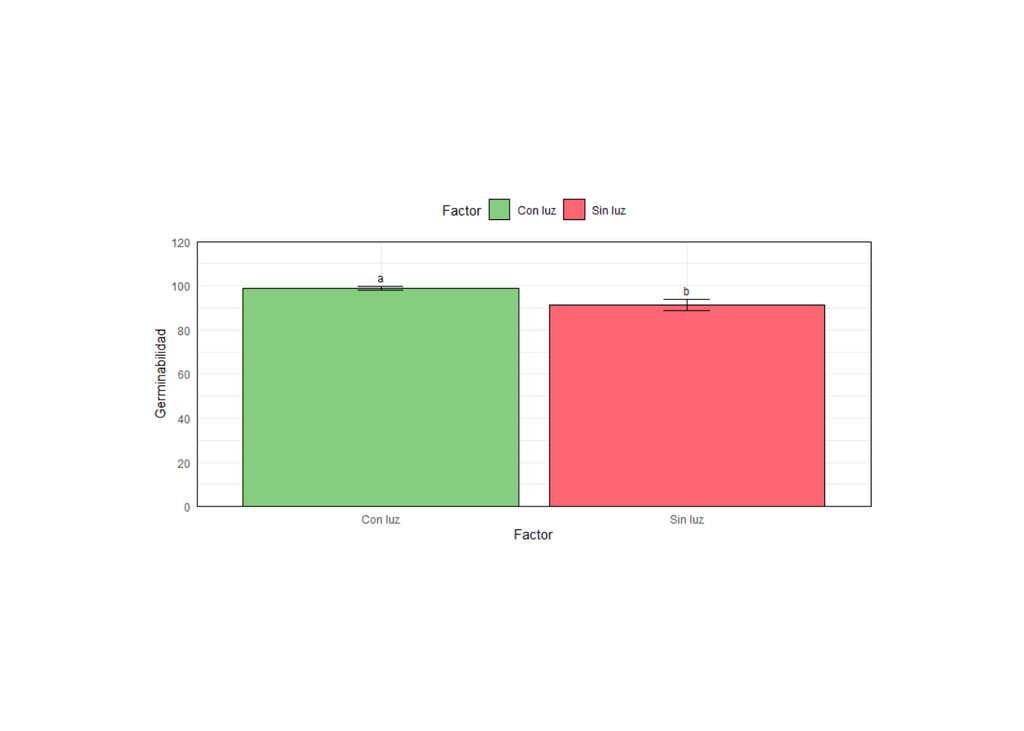

El gráfico de barras compara la germinabilidad (%) entre las dos condiciones. Cada barra presenta una letra encima: “a” para Con luz y “b” para Sin luz, lo que indica que se ha realizado un análisis estadístico. Como se puede apreciar, las letras son diferentes (a ≠ b); por lo tanto, esto significa que existe una diferencia estadísticamente significativa entre los tratamientos.

**ÍNDICE DE SINCRONIZACIÓN**

Exploratorio

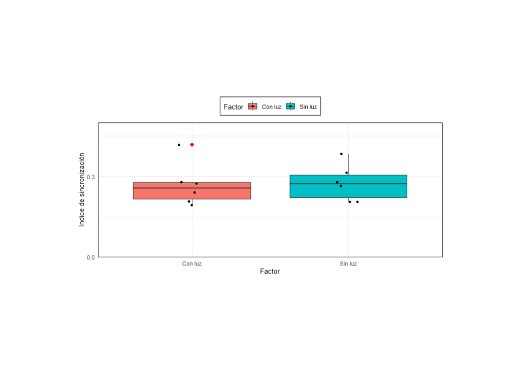

La gráfica es un boxplot (diagrama de caja y bigotes) que compara el Índice de sincronización entre ambos tratamientos: “Con luz” y “Sin luz”. Ambos tratamientos presentan medidas relativamente similares, aunque el grupo “Sin luz” muestra una mediana ligeramente más alta, lo que sugiere una germinación más sincronizada bajo esta condición. La dispersión de los datos es comparable en ambos grupos, indicando una variabilidad similar en la sincronización de la germinación. Sin embargo, en el tratamiento “Con luz” se observan algunos valores atípicos, lo que sugiere que en ciertas réplicas la sincronización fue notablemente diferente respecto al resto, posiblemente debido a condiciones particulares o a la variabilidad natural.

Estadísticas

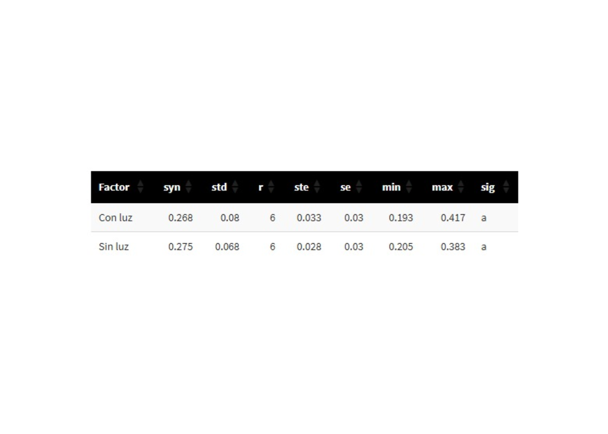

Gráfico

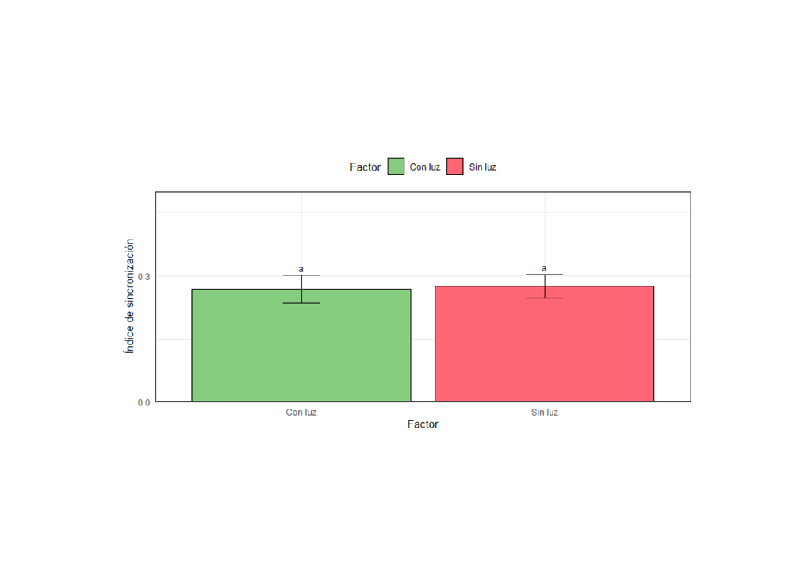

El índice de sincronización mide qué tan juntas en el tiempo germinan las semillas. Tanto en condiciones de luz como de oscuridad, el índice es similar. No se observan diferencias estadísticas entre los tratamientos, como lo indica la presencia de la misma letra (“a”) en ambos grupos. Por lo tanto, se concluye que la luz no afecta la sincronización del proceso de germinación en habas.

**TIEMPO MEDIO DE GERMINACIÓN**

Exploratorio

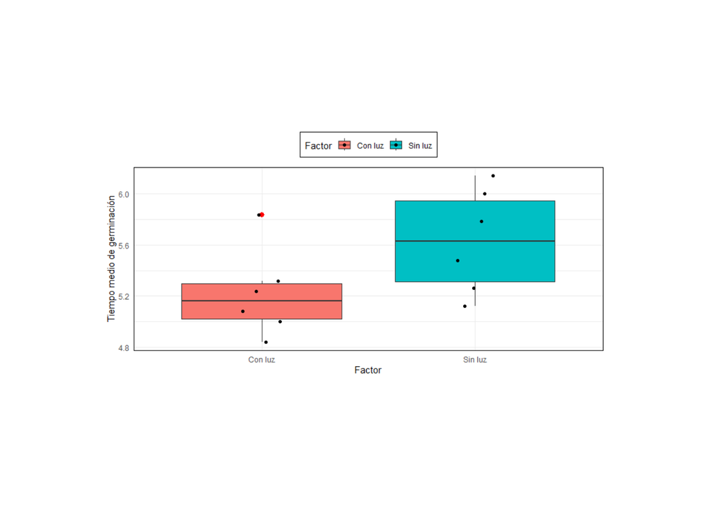

Estadísticas

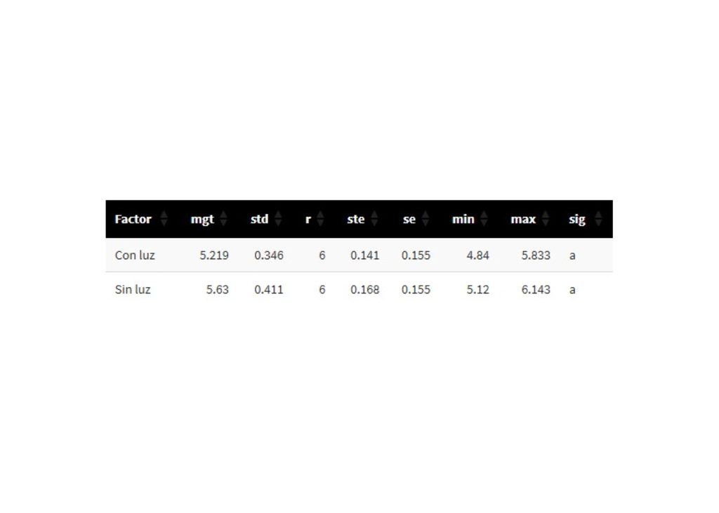

Gráfico

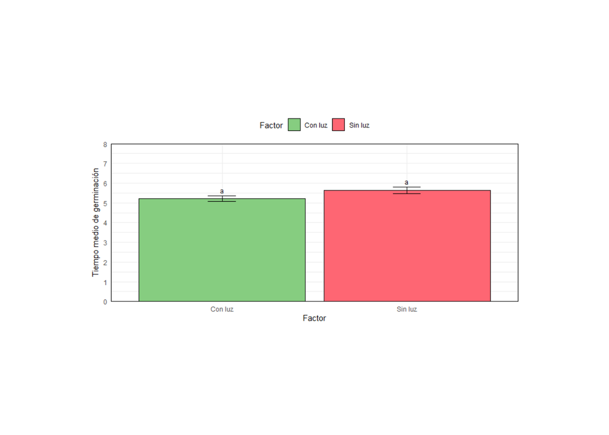

En el gráfico muestra la comparación directa de los promedios de tiempo de germinación: Se confirma que las semillas con luz germinan más rápido que sin luz. Comparten la misma letra”a” por lo cual no hay diferencia significativa entre tratamientos. Llegando a concluir que la luz podría favorecer ligeramente una germinación más rápida, aunque no significativamente.

**PORCENTAJE DE GERMINACIÓN**

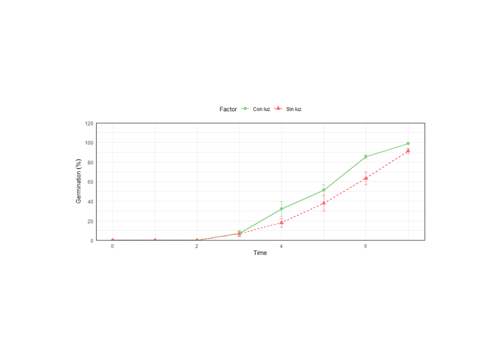

# 5 **DISCUSIÓN**

En el experimento realizado para evaluar la germinación de semillas de haba bajo condiciones de luz y oscuridad, se observaron diferencias evidentes entre los tratamientos. En cuanto al porcentaje de germinación, las semillas expuestas a la presencia de luz alcanzaron valores cercanos al 100 %, mientras que las semillas en ausencia de luz presentaron una germinación ligeramente menor y una mayor dispersión en los datos. El análisis estadístico, representado mediante letras distintas (“a” y “b”), confirma que esta diferencia es significativa.

Respecto al índice de sincronización, ambos tratamientos mostraron valores similares y no se encontraron diferencias estadísticas, por lo que se concluye que la luz no influye en la sincronización del proceso de germinación.

En relación con el tiempo medio de germinación, las semillas germinadas con luz mostraron un tiempo ligeramente menor y una menor variabilidad en comparación con aquellas germinadas sin luz. Aunque esta diferencia no fue significativa, el patrón observado sugiere que la luz podría favorecer una germinación más rápida.

Finalmente, el gráfico de líneas mostró que, bajo condiciones de luz, las semillas germinan antes y alcanzan un porcentaje final de germinación más alto.

# 6 CONCLUSIONES

La luz tiene un efecto positivo en el porcentaje de germinación, pero no afecta significativamente la sincronización ni el tiempo medio del proceso de germinación de las semillas de haba.

# 7 **REFERENCIAS**

Agraria.pe. (2024). Exportaciones peruanas de habas crecieron 44% en volumen en agosto. Agraria.pe. https://agraria.pe/noticias/exportaciones-peruanas-de-habas-crecieron-44-en-volumen-en-a-37215#:~:text=(Agraria.pe)%20Las%20exportaciones,igual%20mes%20del%20a%C3%B1o%20anterior

Arnaud, R., & Georges, F. (2020). Descripción general de Bruchus rufimanus Boheman 1833 (Coleoptera: Chrysomelidae): Biología, ecología química y oportunidades semioquímicas en programas de manejo integrado de plagas. Los frijoles y los guisantes. https://doi.org/10.1016/j.cropro.2020.105411

Horque, R. (2004). Cultivo del haba. INIA - Perú. https://repositorio.inia.gob.pe/server/api/core/bitstreams/715ee52d-6df5-4fdb-886f-f334bf6a8f99/content

INIA - Perú. (2004). Haba INIA 401 - Cusco. INIA. https://repositorio.inia.gob.pe/server/api/core/bitstreams/b7cae603-cf90-42c8-8494-a3cae909a5d2/content

Lepri, A., Kazmi, H., Bertolotti, G., Longo, C., Occhigrossi, S., Quattrocchi, L., & De Vivo, M. (2024). Un bucle de retroalimentación entre giberelinas y represores transcripcionales DOF desempeña un papel crucial en la modulación de la germinación de semillas independiente de la luz. Science. https://doi.org/10.1016/j.xplc.2025.101262

Saavedra, G., & Kehr, E. (2023). Manejo y especies hortícolas aptas para la agroindustria en la Región de La Araucanía. INIA - Chile. https://hdl.handle.net/20.500.14001/68961